# Final Project

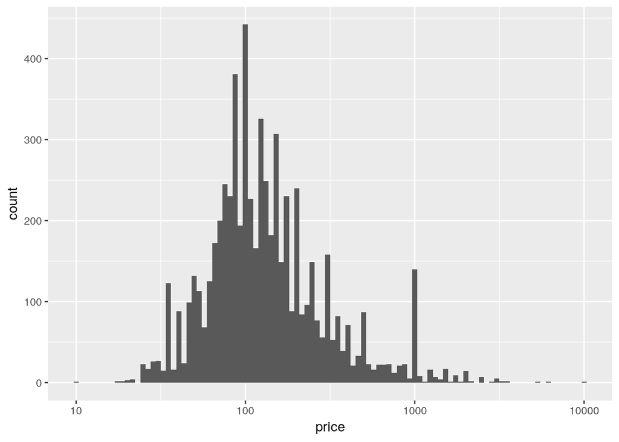

This plot shows the spread of prices for Washington D.C. listings. We use a logarithmic scale for this because there is a huge outlier as one listing has a price of $10,000.

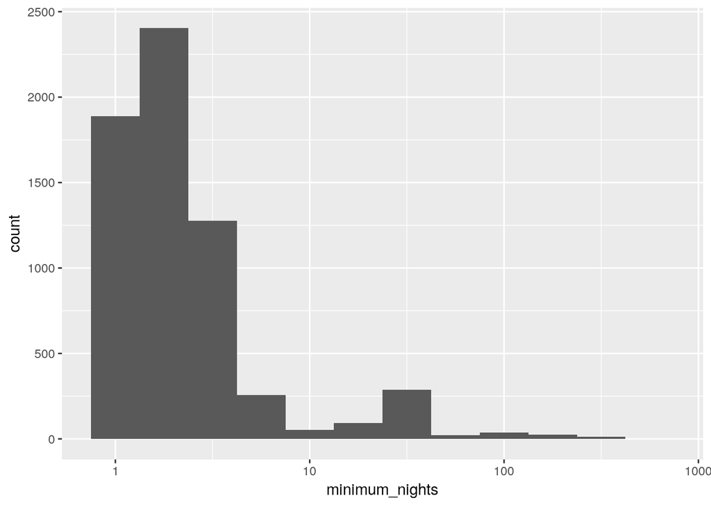

```r
abnb %>%
  ggplot(aes(x = minimum_nights)) +
  geom_histogram(binwidth = .25) +
  scale_x_log10()
```

# Part B

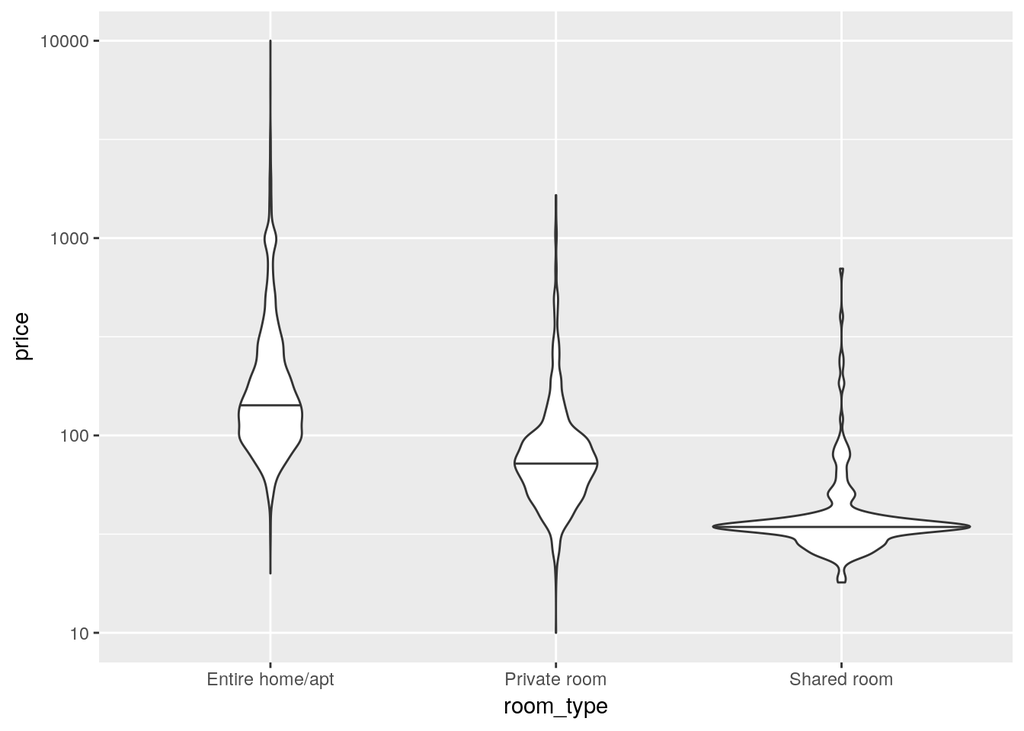

```r
abnb %>%
  ggplot(aes(x= room_type, y = price)) +
  geom_violin(draw_quantiles = .5) +
  scale_y_log10()
```

This plot is a violin plot with the median drawn as a horizontal line. From this plot we can see a possible correlation between price and type of room.

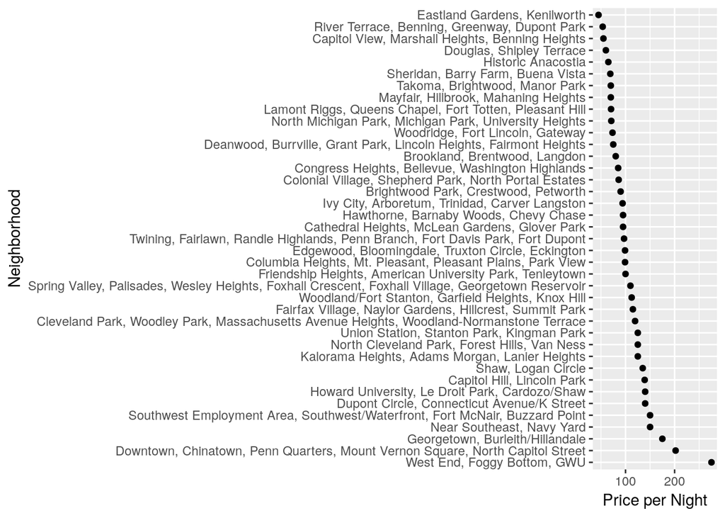

```r
abnb %>%
  group_by(neighbourhood) %>%
  summarize(neigh_med = median(price)) %>%
  ggplot(aes(x=reorder(neighbourhood, -neigh_med), y=neigh_med)) +
  geom_point() +
  labs(x="Neighborhood", y="Price per Night") +
  coord_flip()
```

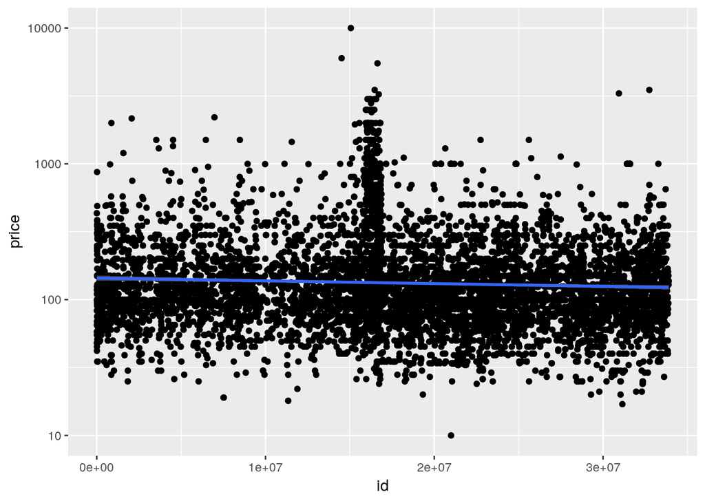

```r
abnb %>%
  ggplot(aes(x = id, y = price)) +
  geom_point() +
  geom_smooth(method = lm) +
  scale_y_log10()
```

# 3. Hypothesis testing